# Lab 9 - Multiple linear regression - KEY

total - 90 pts

#### Load data

```r
load(url("http://www.openintro.org/stat/data/evals.RData"))
```

#### Exercise 1:

```
6pts:
- 3pt for observational study
- 3pt for "association"
```

This was an **observational** study, so any causal claims made about the relationship between professors’ appearances and their evaluations are not justified.

The research question could be rephrased to ask whether beauty is **associated** with higher course evaluations.

#### Exercise 2:

```
6pts:
- 3pts for many points with exact same coords
- 3pts for `jitter` making it clearer how many points lay in the same region
```

The initial scatter plot had many points with the **exact same coordinates**, making it hard to tell where the data was concentrated.

Jittering adds a little random noise to **make it clearer how many points** lay in the region of interest.

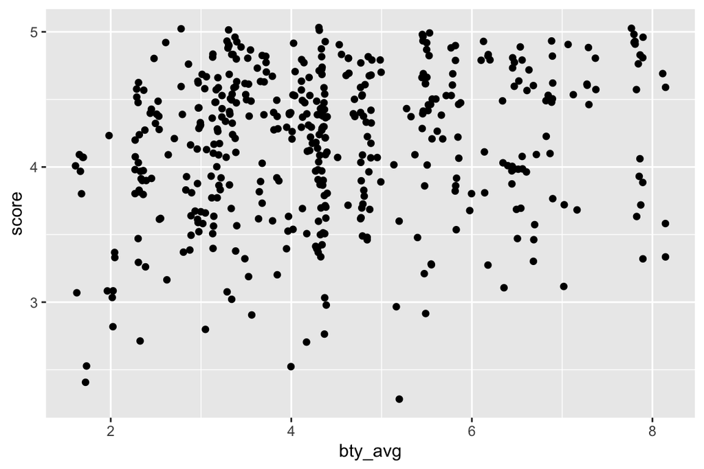

```r
qplot(data = evals, x=bty_avg, y=score, geom="jitter")
```

#### Exercise 3:

```
14pts:
- 3pt for plot
- 3pt for linear model equation
- 3pt for association
- 2pt for "significant predictor"
- 3pt for context
```

```r
m_bty <- lm(evals$score ~ evals$bty_avg, data=evals)
summary(m_bty)
```

```
##
## Call:
## lm(formula = evals$score ~ evals$bty_avg, data = evals)
##
## Residuals:
##     Min      1Q  Median      3Q     Max
## -1.9246 -0.3690  0.1420  0.3977  0.9309
##
## Coefficients:
##               Estimate Std. Error t value Pr(>|t|)
## (Intercept)    3.88034    0.07614   50.96  < 2e-16 ***
## evals$bty_avg  0.06664    0.01629    4.09 5.08e-05 ***
## ---
## Signif. codes:  0 '***' 0.001 '**' 0.01 '*' 0.05 '.' 0.1 ' ' 1
##
## Residual standard error: 0.5348 on 461 degrees of freedom
## Multiple R-squared:  0.03502,    Adjusted R-squared:  0.03293
## F-statistic: 16.73 on 1 and 461 DF,  p-value: 5.083e-05
```

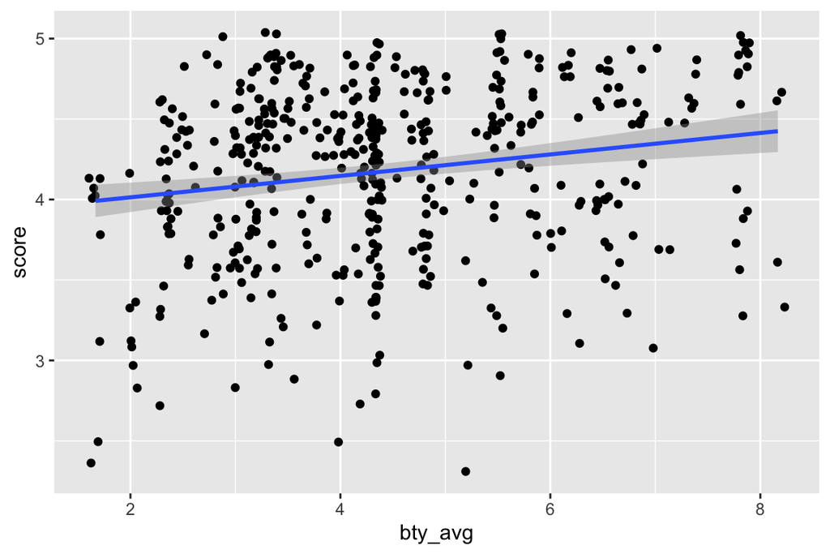

```r
qplot(y=score, x=bty_avg, data=evals, geom="jitter") + geom_smooth(method="lm")
```

The equation for the linear model is
$$\hat{\text{score}_i} = 3.88034 + .06664\times \text{bty_avg}_i.$$

The positive slope means that a professor being more beautiful is **associated with a higher score.** ‘bty_avg’ is a **significant predictor** according to the regression summary. The association is not extremely strong, so it may not be of great practical importance, but that depends upon how professor reviews are used, obviously.

#### Exercise 4:

```
11pts:
- 3pt for fitting the new model
- 4pt for constant variance assumption
- 4pt for normality assumption
```

Fitting the new model:

```r
m_bty_gen <- lm(score ~ bty_avg + gender, data = evals)
summary(m_bty_gen)
```

```
##
## Call:
## lm(formula = score ~ bty_avg + gender, data = evals)
##
## Residuals:
##     Min      1Q  Median      3Q     Max
## -1.8305 -0.3625  0.1055  0.4213  0.9314
##
## Coefficients:
##             Estimate Std. Error t value Pr(>|t|)
## (Intercept)  3.74734    0.08466  44.266  < 2e-16 ***
## bty_avg      0.07416    0.01625   4.563 6.48e-06 ***
## gendermale   0.17239    0.05022   3.433 0.000652 ***
## ---
## Signif. codes:  0 '***' 0.001 '**' 0.01 '*' 0.05 '.' 0.1 ' ' 1
##
## Residual standard error: 0.5287 on 460 degrees of freedom
## Multiple R-squared:  0.05912,    Adjusted R-squared:  0.05503
## F-statistic: 14.45 on 2 and 460 DF,  p-value: 8.177e-07
```

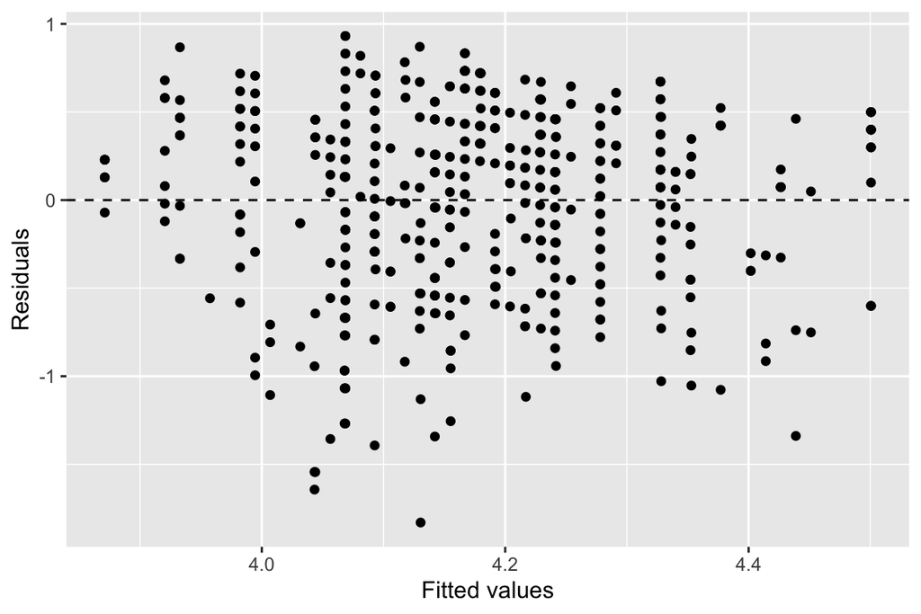

```r
qplot(x = .fitted, y = .resid, data = m_bty_gen) +
  geom_hline(yintercept = 0, linetype = "dashed") +
  xlab("Fitted values") +
  ylab("Residuals")
```

The residuals do not appear to be normally distributed. The histogram is left-skewed and the QQ-plot **shows clear deviations from the diagonal**.

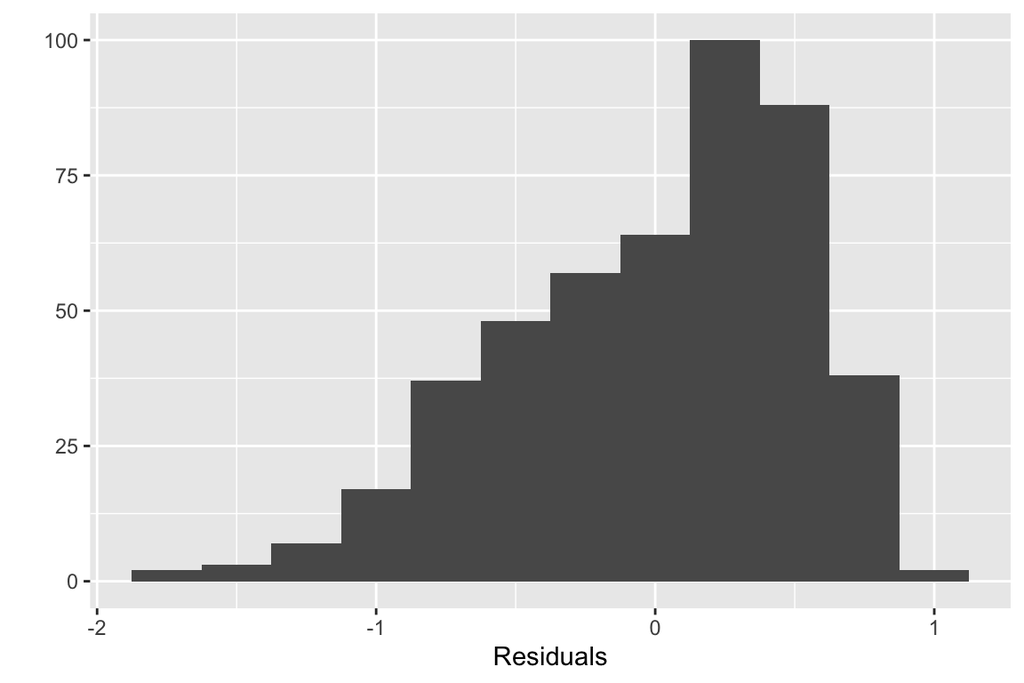

```r
qplot(x = .resid, data = m_bty_gen, geom = "histogram", binwidth = .25) +
  xlab("Residuals")
```

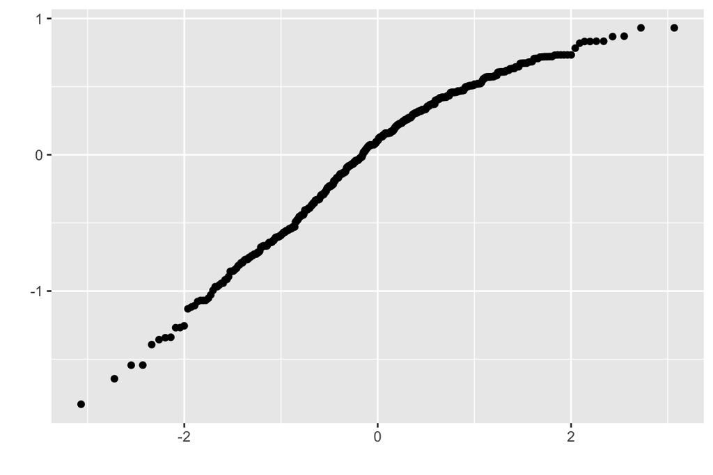

```r
qplot(sample = .resid, data = m_bty_gen, stat = "qq")
```

#### Exercise 5:

```
6pts:
- 3pt for significant predictor
- 3pt for discussing change of coefficients.
```

bty_avg is still a **significant predictor of score**.

The parameter estimate changed from **0.0666** in the model where only bty_avg and the intercept are included to **0.0742** in the model where we also include gender. This **isn’t a huge change**.

#### Exercise 6:

```
6pts:
- 3pt for equation
- 3pt for male tends to have higher score
```

The **equation of the line** corresponding to males is
$$\hat{\text{score}_i} = 3.7473 + 0.0742 \times \text{bty_avg}_i + 1 \times 0.1724$$

The equation tells us that if two professors have the same beauty rating but one is male and the other is female, the **male will tend to have the higher score** This comes from the last term in the above equation.

#### Exercise 7:

```
6pts:
- 3pt for fitting the model
- 3pt for dummy variable levels
```

R creates dummy variables for **all but one of the levels** of the categorical variable.

```r
m_bty_rank <- lm(score ~ bty_avg + rank, data = evals)
summary(m_bty_rank)
```

```
##
## Call:
## lm(formula = score ~ bty_avg + rank, data = evals)
##
## Residuals:
##     Min      1Q  Median      3Q     Max
## -1.8713 -0.3642  0.1489  0.4103  0.9525
##
## Coefficients:
##                  Estimate Std. Error t value Pr(>|t|)
## (Intercept)       3.98155    0.09078  43.860  < 2e-16 ***
## bty_avg           0.06783    0.01655   4.098 4.92e-05 ***
## ranktenure track -0.16070    0.07395  -2.173   0.0303 *
## ranktenured      -0.12623    0.06266  -2.014   0.0445 *
## ---
## Signif. codes:  0 '***' 0.001 '**' 0.01 '*' 0.05 '.' 0.1 ' ' 1
##
## Residual standard error: 0.5328 on 459 degrees of freedom
## Multiple R-squared:  0.04652,    Adjusted R-squared:  0.04029
## F-statistic: 7.465 on 3 and 459 DF,  p-value: 6.88e-05
```

#### Exercise 8:

```
9pts:
- 3pts for fitting the full model and showing the output
- 3pts for the highest p-value variable
- 3pts for the lowest p-value variable
```

```r
m_full <- lm(score ~ rank + ethnicity + gender + language + age + cls_perc_eval
             + cls_students + cls_level + cls_profs + cls_credits + bty_avg
             + pic_outfit + pic_color, data = evals)
summary(m_full)
```

```
##
## Call:
## lm(formula = score ~ rank + ethnicity + gender + language + age +
##     cls_perc_eval + cls_students + cls_level + cls_profs + cls_credits +
##     bty_avg + pic_outfit + pic_color, data = evals)
##
## Residuals:
##      Min       1Q   Median       3Q      Max
## -1.77397 -0.32432  0.09067  0.35183  0.95036
##
## Coefficients:
##                         Estimate Std. Error t value Pr(>|t|)
## (Intercept)            4.0952141  0.2905277  14.096  < 2e-16 ***
## ranktenure track      -0.1475932  0.0820671  -1.798  0.07278 .
## ranktenured           -0.0973378  0.0663296  -1.467  0.14295
## ethnicitynot minority  0.1234929  0.0786273   1.571  0.11698
## gendermale             0.2109481  0.0518230   4.071 5.54e-05 ***
## languagenon-english   -0.2298112  0.1113754  -2.063  0.03965 *
## age                   -0.0090072  0.0031359  -2.872  0.00427 **
## cls_perc_eval          0.0053272  0.0015393   3.461  0.00059 ***
## cls_students           0.0004546  0.0003774   1.205  0.22896
## cls_levelupper         0.0605140  0.0575617   1.051  0.29369
## cls_profssingle       -0.0146619  0.0519885  -0.282  0.77806
## cls_creditsone credit  0.5020432  0.1159388   4.330 1.84e-05 ***
## bty_avg                0.0400333  0.0175064   2.287  0.02267 *
## pic_outfitnot formal  -0.1126817  0.0738800  -1.525  0.12792
## pic_colorcolor        -0.2172630  0.0715021  -3.039  0.00252 **
## ---
## Signif. codes:  0 '***' 0.001 '**' 0.01 '*' 0.05 '.' 0.1 ' ' 1
##
## Residual standard error: 0.498 on 448 degrees of freedom
## Multiple R-squared:  0.1871, Adjusted R-squared:  0.1617
## F-statistic: 7.366 on 14 and 448 DF,  p-value: 6.552e-14
```

`cls_profs` (number of professors teaching the class) has the highest p-value.

`cls_credits` is most likely to be significantly associated with the score of professors. (Pick the one with the lowest p-value.)

#### Exercise 9:

```
6pts:
- 3pts for statement like "all else held constant"
- 3pts for change in professor score if instructor is non-minority
```

Being a non-minority is associated with a higher score. In particular, with all other variables held constant, non-minority instructors have scores .12 points higher, on average.

#### Exercise 10:

```
10pts:
- 3pt for choosing the correct variable to remove
- 3pt for fitting model
- 4pt for discussion
```

**cls_profs** had the highest p-value, so we’ll **remove it from the model**.

```r
m_full <- lm(score ~ rank + ethnicity + gender + language + age + cls_perc_eval
             + cls_students + cls_level + cls_credits + bty_avg
             + pic_outfit + pic_color, data = evals)
summary(m_full)
```

```
##
## Call:
## lm(formula = score ~ rank + ethnicity + gender + language + age +
##     cls_perc_eval + cls_students + cls_level + cls_credits +
##     bty_avg + pic_outfit + pic_color, data = evals)
##
## Residuals:
##     Min      1Q  Median      3Q     Max
## -1.7836 -0.3257  0.0859  0.3513  0.9551
##
## Coefficients:
##                         Estimate Std. Error t value Pr(>|t|)
## (Intercept)            4.0872523  0.2888562  14.150  < 2e-16 ***
## ranktenure track      -0.1476746  0.0819824  -1.801 0.072327 .
## ranktenured           -0.0973829  0.0662614  -1.470 0.142349
## ethnicitynot minority  0.1274458  0.0772887   1.649 0.099856 .
## gendermale             0.2101231  0.0516873   4.065 5.66e-05 ***
## languagenon-english   -0.2282894  0.1111305  -2.054 0.040530 *
## age                   -0.0089992  0.0031326  -2.873 0.004262 **
## cls_perc_eval          0.0052888  0.0015317   3.453 0.000607 ***
## cls_students           0.0004687  0.0003737   1.254 0.210384
## cls_levelupper         0.0606374  0.0575010   1.055 0.292200
## cls_creditsone credit  0.5061196  0.1149163   4.404 1.33e-05 ***
## bty_avg                0.0398629  0.0174780   2.281 0.023032 *
## pic_outfitnot formal  -0.1083227  0.0721711  -1.501 0.134080
## pic_colorcolor        -0.2190527  0.0711469  -3.079 0.002205 **
## ---
## Signif. codes:  0 '***' 0.001 '**' 0.01 '*' 0.05 '.' 0.1 ' ' 1
##
## Residual standard error: 0.4974 on 449 degrees of freedom
## Multiple R-squared:  0.187,  Adjusted R-squared:  0.1634
## F-statistic: 7.943 on 13 and 449 DF,  p-value: 2.336e-14
```

It doesn’t appear that the direction of any of the coefficient estimates changed, but the **magnitudes changed at least slightly**. If the dropped variable was **collinear, then we might expect sign changes or big changes in magnitude**.

#### Exercise 11:

```
10pts:
- 4pts for listing the variables removed in backward elimination
- 3pts for output of the final model (all p-values should be < 0.05)
- 3pts for writing out the formula
```

```r
final_model <- lm(score ~  ethnicity + gender + language + age + cls_perc_eval + cls_credits + bty_avg + pic_color, data = evals)
summary(final_model)
```

```
##
## Call:
## lm(formula = score ~ ethnicity + gender + language + age + cls_perc_eval +
##     cls_credits + bty_avg + pic_color, data = evals)
##
## Residuals:
##      Min       1Q   Median       3Q      Max
## -1.85320 -0.32394  0.09984  0.37930  0.93610
##
## Coefficients:
##                        Estimate Std. Error t value Pr(>|t|)
## (Intercept)            3.771922   0.232053  16.255  < 2e-16 ***
## ethnicitynot minority  0.167872   0.075275   2.230  0.02623 *
## gendermale             0.207112   0.050135   4.131 4.30e-05 ***
## languagenon-english   -0.206178   0.103639  -1.989  0.04726 *
## age                   -0.006046   0.002612  -2.315  0.02108 *
## cls_perc_eval          0.004656   0.001435   3.244  0.00127 **
## cls_creditsone credit  0.505306   0.104119   4.853 1.67e-06 ***
## bty_avg                0.051069   0.016934   3.016  0.00271 **
## pic_colorcolor        -0.190579   0.067351  -2.830  0.00487 **
## ---
## Signif. codes:  0 '***' 0.001 '**' 0.01 '*' 0.05 '.' 0.1 ' ' 1
##
## Residual standard error: 0.4992 on 454 degrees of freedom
## Multiple R-squared:  0.1722, Adjusted R-squared:  0.1576
## F-statistic:  11.8 on 8 and 454 DF,  p-value: 2.58e-15
```